# **Introduction to Data Science Using R - Tutorial**

**Paul Armstrong CMSC320 Section 0101**

### **Information and Requirements**

This is a tutorial introduction to data science using R. The tutorial covers the following topics:

- Data Collection
- Imputation
- Simple Plots and Analysis
- Hypothesis Testing
- Linear Regression
- Interactive Geographic Visualizations

For this tutorial you will need RStudio with the *tidyverse* and *leaflet* packages. You should open up a new blank R script and include the libraries like this:

```r
library(tidyverse)
library(leaflet)
```

Content in the tutorial is organized by topic. There will be explanations of topics and R concepts, with code and output to accompany them. **Names of important functions mentioned and used during the tutorial will link to more information.**

You may also want to consult the resources at the bottom for more information about certain topics.

### **Data Collection**

We are using a dataset from the US Department of Transportation about Airports. There is an [informational page about the dataset](http://osav-usdot.opendata.arcgis.com/datasets/a36a509eab4e43b4864fb594a35b90d6_0) and also a direct URL to get the CSV file. We will use the direct .csv link to load the dataset into R.

```r
airports <- read_csv("http://osav-usdot.opendata.arcgis.com/datasets/a36a509eab4e43b4864fb594a35b90d6_0.csv")
```

R interprets this CSV file as a rectangular data frame. This means that it is two dimensional data, so it can be represented as a table. Each row of the table is called an entity, an entity has entries for each attribute. Each column of the table corresponds to an attribute. This particular rectangular data frame is pretty large with 19460 rows and 101 columns. That means there are 19000 airports in the data frame and 101 attributes.

101 attributes is more than we will use for the purposes of this tutorial. The `colnames` function can be used to get a list of all of the column names. We’ll use colnames to look at the first 20 column names.

```r
colnames(airports)[1:20]
```

```
##  [1] "X"                    "Y"                    "OBJECTID"
##  [4] "SiteNumber"           "FacilityType"         "LocationID"
##  [7] "EffectiveDate"        "RegionCode"           "DistrictCode"
## [10] "StateAbbv"            "StateName"            "County"
## [13] "CountyPostOfficeCode" "City"                 "FullName"
## [16] "OwnerType"            "FacilityUse"          "CoordDet"
## [19] "Elevation"            "ElevDet"
```

You can see that there are a lot of interesting attributes. For this tutorial we will use:

- LocationID
- FullName
- X
- Y
- Elevation
- FacilityType
- Acres
- hasTower
- Passengers

In order to pick only these attributes we’ll use the [`select`](https://www.rdocumentation.org/packages/dplyr/versions/0.7.8/topics/select) function. The function should be given the data frame, and the names of the attributes to preserve.

```r
airports <- select(airports, LocationID, FullName, X, Y, Elevation, FacilityType, Acres, hasTower, Passengers)

airports
```

```
## # A tibble: 19,460 x 9
##    LocationID FullName     X     Y Elevation FacilityType Acres hasTower
##    <chr>      <chr>    <dbl> <dbl>     <dbl> <chr>        <dbl> <chr>
##  1 AL83       Communi~ -85.9  32.5      400  Heliport         1 N
##  2 5AL2       Midstre~ -88.1  30.5        0  Heliport        13 N
##  3 2AL6       Dale O ~ -88.2  30.5       40  Airport         17 N
##  4 AL48       Southwe~ -87.7  31.9      265  Heliport        NA N
##  5 3AL7       Flowers~ -87.5  32.3      280  Airport         NA N
##  6 TOI        Troy Mu~ -86.0  31.9      397. Airport        501 Y
##  7 AL77       Smart R~ -86.0  31.7      425  Airport         NA N
##  8 TCL        Tuscalo~ -87.6  33.2      170  Airport        724 Y
##  9 AL26       Bryant ~ -87.5  33.2      283  Heliport        NA N
## 10 3AL3       Tuscalo~ -87.6  33.2      160  Heliport        NA N
## # ... with 19,450 more rows, and 1 more variable: Passengers <dbl>
```

Great! Now we have gone from 101 attributes to the 9 that we are interested in. Now, there are a lot of helipads, seaports, airstrips, and other types of facilities in this data set. We want to look at commercial airports, so we will filter out these entities. To do this we will filter out all entities where FacilityType is not Airport or there are less than 100,000 passengers served. The [`filter`](https://www.rdocumentation.org/packages/dplyr/versions/0.7.8/topics/filter) function can be used to achieve this. It removes all elements where any of the provided predicates are false. Also, we can use the special syntax of [`select`](https://www.rdocumentation.org/packages/dplyr/versions/0.7.8/topics/select) to remove the unnecessary FacilityType attribute.

```r
airports <- filter(airports, FacilityType == "Airport", Passengers >= 100000)
airports <- select(airports, -FacilityType)

airports
```

```
## # A tibble: 224 x 8
##    LocationID FullName          X     Y Elevation Acres hasTower Passengers
##    <chr>      <chr>         <dbl> <dbl>     <dbl> <dbl> <chr>         <dbl>
##  1 XNA        Northwest A~  -94.3  36.3    1288    2184 Y            699281
##  2 LIT        Bill And Hi~  -92.2  34.7     266    2000 Y            990340
##  3 IFP        Laughlin/Bu~ -115.   35.2     701     650 Y            117808
##  4 GCN        Grand Canyo~ -112.   36.0    6609     859 Y            104898
##  5 PHX        Phoenix Sky~ -112.   33.4    1135    3400 Y          19353344
##  6 TUS        Tucson Intl  -111.   32.1    2643.   7938 Y           1685121
##  7 BUR        Bob Hope     -118.   34.2     778.    614 Y           2212865
##  8 FAT        Fresno Yose~ -120.   36.8     336.   1728 Y            653681
##  9 LGB        Long Beach ~ -118.   33.8      60.3  1166 Y           1832702
## 10 LAX        Los Angeles~ -118.   33.9     128.   3500 Y          26460287
## # ... with 214 more rows
```

### **Imputation**

Unfortunately, there is some data missing for the Acres attribute. In order to compensate for this missing data we will set each missing value to be the average of all actual values. This means that the overall mean for the attribute will stay the same, but the spread of the attribute will be affected.

The **mutate** function is used to modify an existing attribute or create a new attribute for each entity. The [`ifelse`](https://www.rdocumentation.org/packages/base/versions/3.6.0/topics/ifelse) function is similar to the ternary expression in Java. `mean(airports$Acres, na.rm = TRUE)` gets the mean of Acres, excluding undefined values.

```r
airports <- mutate(airports, Acres = ifelse(is.na(Acres), mean(airports$Acres, na.rm = TRUE), Acres))

airports
```

```
## # A tibble: 224 x 8
##    LocationID FullName          X     Y Elevation Acres hasTower Passengers
##    <chr>      <chr>         <dbl> <dbl>     <dbl> <dbl> <chr>         <dbl>
##  1 XNA        Northwest A~  -94.3  36.3    1288    2184 Y            699281
##  2 LIT        Bill And Hi~  -92.2  34.7     266    2000 Y            990340
##  3 IFP        Laughlin/Bu~ -115.   35.2     701     650 Y            117808
##  4 GCN        Grand Canyo~ -112.   36.0    6609     859 Y            104898
##  5 PHX        Phoenix Sky~ -112.   33.4    1135    3400 Y          19353344
##  6 TUS        Tucson Intl  -111.   32.1    2643.   7938 Y           1685121
##  7 BUR        Bob Hope     -118.   34.2     778.    614 Y           2212865
##  8 FAT        Fresno Yose~ -120.   36.8     336.   1728 Y            653681
##  9 LGB        Long Beach ~ -118.   33.8      60.3  1166 Y           1832702
## 10 LAX        Los Angeles~ -118.   33.9     128.   3500 Y          26460287
## # ... with 214 more rows
```

### **A Quick Aside for the Pipe Operator**

The tidyverse library adds support for the pipe operator [`%>%`](https://www.rdocumentation.org/packages/magrittr/versions/1.5/topics/%25%3E%25), which allows for some cleaner syntax when modifying the data frame. It passes the left side of the operator as the first argument in the function on the right side of the operator. Look at how everything we have done so far can be done sequentially using the pipe operator.

```r
airports <-
  read_csv("http://osav-usdot.opendata.arcgis.com/datasets/a36a509eab4e43b4864fb594a35b90d6_0.csv") %>%
  select(LocationID, FullName, X, Y, Elevation, FacilityType, Acres, hasTower, Passengers) %>%
  filter(FacilityType == "Airport", Passengers >= 100000) %>%
  select(-FacilityType) %>%
  mutate(Acres = ifelse(is.na(Acres), mean(.$Acres, na.rm = TRUE), Acres))
```

### **Simple Plots and Analysis**

Let’s start with plots and analysis by creating a bar graph showing the average airport size for airports with and without an air traffic control tower. For this we will use the [`group_by`](https://www.rdocumentation.org/packages/dplyr/versions/0.7.8/topics/group_by) and [`summarize`](https://www.rdocumentation.org/packages/dplyr/versions/0.7.8/topics/summarise) functions, and [`ggplot`](https://ggplot2.tidyverse.org/reference/).

- The [`group_by`](https://www.rdocumentation.org/packages/dplyr/versions/0.7.8/topics/group_by) function allows us to put entities into separate buckets.
- The [`summarize`](https://www.rdocumentation.org/packages/dplyr/versions/0.7.8/topics/summarise) function allows us to make generalizations about each bucket.

We’ll also mutate so that instead of “Y” and “N”, hasTower’s values are “With Control Tower” and “Without Control Tower.”

```r
airports_tower_summarize <- airports %>%
  group_by(hasTower) %>%
  summarize(MeanAcres = mean(Acres)) %>%
  mutate(hasTower = ifelse(hasTower == "Y", "With Control Tower", "Without Control Tower"))

airports_tower_summarize
```

```
## # A tibble: 2 x 2
##   hasTower              MeanAcres
##   <chr>                     <dbl>
## 1 Without Control Tower     1637.
## 2 With Control Tower        2862.
```

The hasTower attribute is a categorical, meaning that its values assume a reasonable finite number of possibilities. In this case it takes on either “With Control Tower” or “Without Control Tower”. Bar graphs are good at presenting a categorical value on the x-axis, and a numerical value on the y-axis.

When using ggplot to create a bar graph, we specify that the x-axis should be hasTower, and the y-axis should be MeanAcres. Then we “add” `geom_col` to specify that we want a bar graph. Finally, the `labs` addition is an optional way to style the text on the graph.

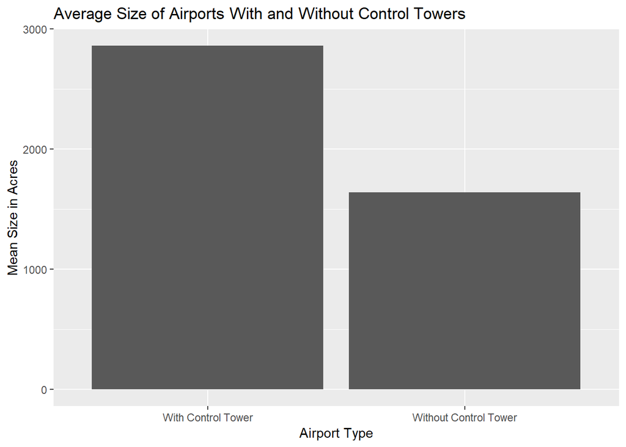

```r
airports_tower_summarize %>%
  ggplot(mapping = aes(x = hasTower, y = MeanAcres)) +
  geom_col() +
  labs(
    title = "Average Size of Airports With and Without Control Towers",
    x = "Airport Type", y = "Mean Size in Acres"
  )
```

With that plot it is clear that airports with control towers are larger on average.

Let’s create a scatterplot to show the Passengers and Acreage for the top 10 busiest airports.

We will use the [`arrange`](https://www.rdocumentation.org/packages/dplyr/versions/0.7.8/topics/arrange) function to arrange the plot in descending Passengers order. Then we can use the [`slice`](https://www.rdocumentation.org/packages/dplyr/versions/0.7.8/topics/slice) function to get the first 10. These are the top 10 busiest airports.

```r
airports_top_10 <- airports %>%
  arrange(desc(Passengers)) %>%
  slice(1:10)

airports_top_10
```

```
## # A tibble: 10 x 8
##    LocationID FullName          X     Y Elevation Acres hasTower Passengers
##    <chr>      <chr>         <dbl> <dbl>     <dbl> <dbl> <chr>         <dbl>
##  1 ATL        Hartsfield ~  -84.4  33.6    1026.   4700 Y          40730454
##  2 ORD        Chicago O'h~  -87.9  42.0     672.   7627 Y          30477266
##  3 DEN        Denver Intl  -105.   39.9    5434.  33531 Y          28578799
##  4 LAX        Los Angeles~ -118.   33.9     128.   3500 Y          26460287
##  5 DFW        Dallas/Fort~  -97.0  32.9     607   17207 Y          22429234
##  6 LAS        Mc Carran I~ -115.   36.1    2181.   2800 Y          20845269
##  7 SEA        Seattle-Tac~ -122.   47.4     432.   2500 Y          19805928
##  8 PHX        Phoenix Sky~ -112.   33.4    1135    3400 Y          19353344
##  9 CLT        Charlotte/D~  -80.9  35.2     748    5000 Y          19221493
## 10 SFO        San Francis~ -122.   37.6      13.2  5207 Y          19175977
```

We can see a few familiar airport codes like ATL and LAX high in the list.

Now we will use the [`ggplot`](https://ggplot2.tidyverse.org/reference/) function to create the plot. Like before we assign attributes to the x and y axies, but we add `geom_point` this time to specify that we want a scatterplot. The `geom_text`, `labs`, and `scale_x_continuous` are optional functions for formatting.

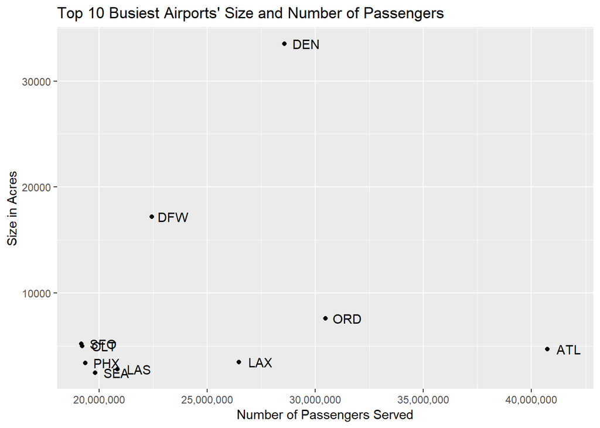

```r
airports_top_10 %>%
  ggplot(mapping = aes(x = Passengers, y = Acres)) +
  geom_point() +
  geom_text(label = airports_top_10$LocationID, nudge_x = 10e5) +
  labs(
    title = "Top 10 Busiest Airports' Size and Number of Passengers",
    x = "Number of Passengers Served", y = "Size in Acres"
  ) +
  scale_x_continuous(labels = scales::comma)
```

Let’s do another scatterplot for all airports. We will not be able to include labels this time because there are so many airports.

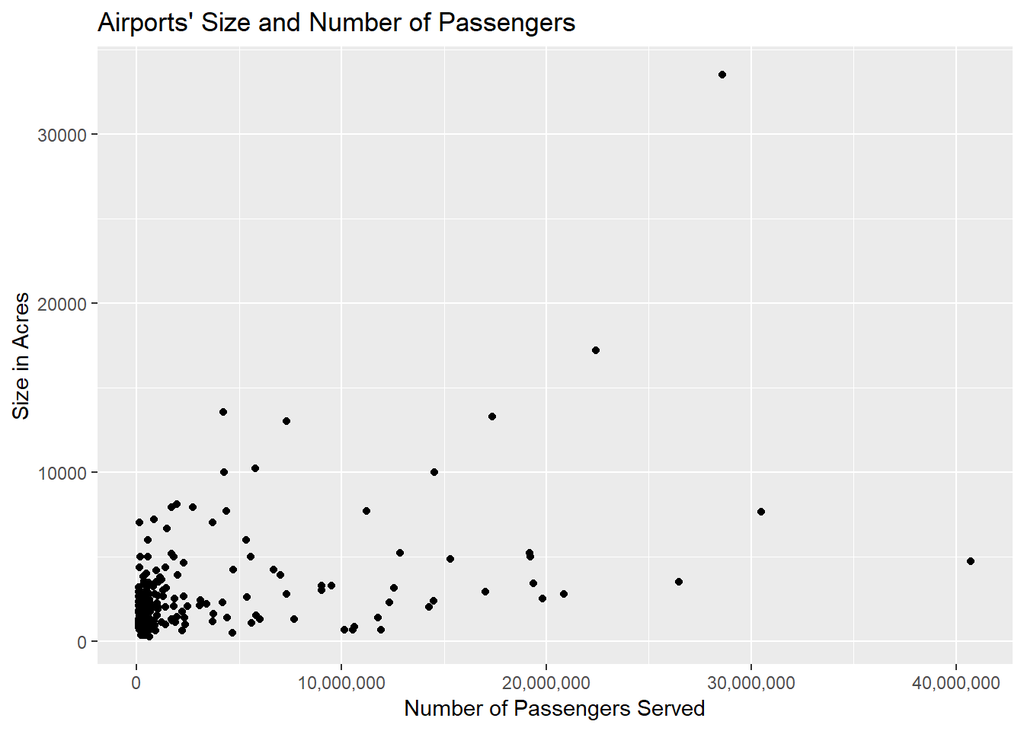

```r
airports %>%
  ggplot(mapping = aes(x = Passengers, y = Acres)) +
  geom_point() +
  labs(
    title = "Airports' Size and Number of Passengers",
    x = "Number of Passengers Served", y = "Size in Acres"
  ) +
  scale_x_continuous(labels = scales::comma)
```

It definitely looks like there is a relationship between number of passengers and airport size.

### **Hypothesis Testing**

Let’s find out if there is a relationship between airport size and number of passengers served. We’ll use hypothesis testing to do this. With hypothesis testing there are normally two hypotheses that we want to put against eachother:

- $H_0$ (The Null Hypothesis) : The default assumption.
- $H_1$ (The Alternative Hypothesis) : A different assumption.

For this situation we will define $H_0$ and $H_1$ as:

- $H_0$ (The Null Hypothesis) : There is not a relationship between number of passengers and airport size.
- $H_1$ (The Alternative Hypothesis): There is a relationship between number of passengers and airport size.

Generally, in order to decide which hypothesis is most correct, we need to see whether or not we can reject the null hypothesis. In order to reject the null hypothesis, there must be a statistically significant indication of the truth of the alternative hypothesis.

In this situation, we will perform linear regression to find an estimate for the relationship between passengers and airport size, and will use the p-value, an indication of significance, to determine whether or not we can reject the null hypothesis. The p-value must be below 0.05 (an arbitrary threshold of statistical significance) for us to reject the null hypothesis.

### **Linear Regression**

Linear regression is a method of approximating an attribute using one or more other attributes. A linear model is used to define which attributes are used to make the prediction. For this situation our linear model will be:

$Y = B_0 + B_1 * X$

- $Y$ is the prediction of airport size (Acres)
- $X$ is the predictor attribute number of passengers served (Passengers)
- $B_0$ is the intercept which will be found through linear regression
- $B_1$ is the weight of X, which will be found through linear regression

We will use the [`lm`](https://www.rdocumentation.org/packages/stats/versions/3.6.0/topics/lm) function to perform the linear regression. This function does a gradient descent to find values of $B_0$ and $B_1$ which will minimize the residual sum of squares (RSS), which is the sum of squared distances from the line $Y = B_0 + B_1 * X$ to each point. The `broom::tidy` function provides information about the linear regression.

```r
size_on_passengers = lm(Acres ~ Passengers, data = airports)

size_on_passengers %>% broom::tidy()
```

```
## # A tibble: 2 x 5
##   term           estimate   std.error statistic  p.value
##   <chr>             <dbl>       <dbl>     <dbl>    <dbl>
## 1 (Intercept) 2040.       213.             9.58 2.07e-18
## 2 Passengers     0.000249   0.0000314      7.92 1.16e-13
```

The “Intercept” estimate is $B_0$ and the “Passengers” estimate is $B_1$. As you can see, there is a p-value given for the intercept and passengers estimates. A lower p-value indicates a better probability of an actual relationship.

Going back to our hypothesis testing, since both of the p-values are below 0.05, we can reject the null hypothesis that there is no relationship, and accept that there is a relationship between number of passengers served and airport size.

Let’s put this line on the scatterplot of airports’ size and number of passengers. We’ll use `geom_smooth` with `method = lm`. This means that it will call the [`lm`](https://www.rdocumentation.org/packages/stats/versions/3.6.0/topics/lm) function to find the intercept and slope of the line.

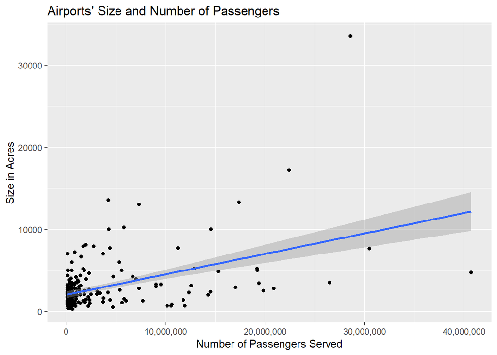

```r
airports %>%
  ggplot(mapping = aes(x = Passengers, y = Acres)) +
  geom_point() +
  labs(
    title = "Airports' Size and Number of Passengers",
    x = "Number of Passengers Served", y = "Size in Acres"
  ) +
  scale_x_continuous(labels = scales::comma) +
  geom_smooth(method = lm)
```

The line has a y-intercept the same as the estimate of $B_0$, and the slope is harder to tell because the x-axis and y-axis are scaled differently on the graph, but it is the same as $B_1$.

As you can see, the line is basically the line of best fit for the points on the plot. This is because it minimizes the residual sum of squares (RSS).

### **Interactive Geographic Visualization**

Let’s use Leaflet to create some geographic visualizations of the data. First we’ll plot the 25 busiest airports. We can find these airports by using the same combination of arrange and slice as with the top 10 airports.

```r
airports_top_25 <- airports %>%
  arrange(desc(Passengers)) %>%
  slice(1:25)
```

Leaflet needs latitude and longitude in order to place markers on the map. Luckily our dataset includes these encoded as the X and Y attributes.

We provide the top 25 airports data to [`leaflet`](https://rstudio.github.io/leaflet/) and `addTiles`, tell [`addMarkers`](https://rstudio.github.io/leaflet/markers.html) to look at X and Y for the latitude and longitude, and call the `setView` function to set the view to North America.

```r
airports_top_25 %>%
  leaflet() %>%
  addTiles() %>%
  setView(lat = 40.0959597, lng = -96.9522955, zoom = 4) %>%
  addMarkers(~X, ~Y)
```

[interactive chart not shown]

You can zoom and pan to see that these busy airports are located in some of the largest cities in the United States.

There are a few things we can do to make the map better and provide more information.

Firstly, we can switch from the default markers in addMarker to the [`awesomeMarkers`](https://rstudio.github.io/leaflet/markers.html), which allow us to use different colors and icons. We’ll define an icon/marker for the airports. It can have a white airplane icon from ionicons, and a red marker color.

```r
airport_icon <- awesomeIcons(
  icon = "airplane",
  iconColor = "white",
  library = "ion",
  markerColor = "red"
)
```

Leaflet lets us specify text for a label, which displays in a dialog box when the mouse goes over a marker. We will use this to provide a small amount of information about each airport.

Leaflet also lets us specify text for a popup, which displays in a popup box when a marker is clicked on. HTML tags are allowed for the popup text. We will use this to provide the full name of the airport, the number of passengers, and the size of the airport. Notice how I used the HTML `<b>` tag to bold the name of the airport, and the `<br>` tag to create line breaks.

```r
airports <- airports %>%
  mutate(LabelText = paste(sep = "", LocationID, ", ", signif(Passengers/10e5, 3), " million passengers")) %>%
  mutate(PopupText = paste(sep = "",
    "<b>", FullName, "</b><br>",
    signif(Passengers/10e5, 3), " million passengers<br>",
    Acres, " acres"
  ))
```

I’m going to use a left_join to apply this to the airports_top_25 as well.

The [`left_join`](https://www.rdocumentation.org/packages/plyr/versions/1.8.4/topics/join) creates an augmented version of the data frame on the left by adding any other attributes from the right.

In this case it will pick up the LabelText and PopupText attributes for the top 25 airports.

```r
airports_top_25 <- airports_top_25 %>% left_join(airports)
```

Doing a similar map to before but calling [`addAwesomeMarkers`](https://rstudio.github.io/leaflet/markers.html) with the airport_icon, label text, and popup text gives us this map.

```r
airports_top_25 %>%
  leaflet() %>%
  addTiles() %>%
  setView(lat = 40.0959597, lng = -96.9522955, zoom = 4) %>%
  addAwesomeMarkers(~X, ~Y, icon = airport_icon, label = ~LabelText, popup = ~PopupText)
```

[interactive chart not shown]

The airplane icon doesn’t load on certain devices, but the red marker looks fine without it.

Another feature of Leaflet markers are the [marker clusters](https://rstudio.github.io/leaflet/markers.html). This is an option which, based on the camera zoom, groups close markers together.

Let’s try this for our airports. We’ll zoom out a little bit because there are more airports outside of mainland USA. Also, let’s use the same label text and popup text from before.

```r
airports %>%
  leaflet() %>%
  addTiles() %>%
  setView(lat = 40.0959597, lng = -96.9522955, zoom = 3) %>%
  addAwesomeMarkers(~X, ~Y, icon = airport_icon, label = ~LabelText, popup = ~PopupText,
    clusterOptions = markerClusterOptions()
  )
```

[interactive chart not shown]

It would be nice to have a way to switch between the top 25 airports and the cluster of all airports. For this, we can assign each to a different leaflet layer group, and have a panel to switch between the two.

The [`addLayersControl`](https://rstudio.github.io/leaflet/showhide.html) function allows us to create an layer option panel in the corner of the map, to switch between groups. Groups are assigned in the addMarkers/AddAwesomeMarker function call.

```r
airports %>%
  leaflet() %>%
  addTiles() %>%
  setView(lat = 40.0959597, lng = -96.9522955, zoom = 3) %>%
  addAwesomeMarkers(data = airports_top_25, ~X, ~Y, icon = airport_icon, label = ~LabelText,
    popup = ~PopupText, group = "25 Busiest Airports"
  ) %>%
  addAwesomeMarkers(~X, ~Y, icon = airport_icon, label = ~LabelText,
    popup = ~PopupText, group = "All Large Airports", clusterOptions = markerClusterOptions()
  ) %>%
  addLayersControl(baseGroups = c("25 Busiest Airports", "All Large Airports"),
    options = layersControlOptions(collapsed = FALSE)
  )
```

[interactive chart not shown]

### **Conclusion**

This is the end of my data science with R introduction tutorial. You have now been exposed to certain data science concepts, and some of the things possible with R and RStudio.

I hope that this tutorial has been useful and thank you for reading.

### **Sources/Useful Resources**

Information about [`ifelse`](https://www.rdocumentation.org/packages/base/versions/3.6.0/topics/ifelse), [`select`](https://www.rdocumentation.org/packages/dplyr/versions/0.7.8/topics/select), [`filter`](https://www.rdocumentation.org/packages/dplyr/versions/0.7.8/topics/filter), [`mutate`](https://www.rdocumentation.org/packages/dplyr/versions/0.7.8/topics/mutate), [`group_by`](https://www.rdocumentation.org/packages/dplyr/versions/0.7.8/topics/group_by), [`summarize`](https://www.rdocumentation.org/packages/dplyr/versions/0.7.8/topics/summarise), [`arrange`](https://www.rdocumentation.org/packages/dplyr/versions/0.7.8/topics/arrange), [`slice`](https://www.rdocumentation.org/packages/dplyr/versions/0.7.8/topics/slice), [`lm`](https://www.rdocumentation.org/packages/stats/versions/3.6.0/topics/lm), [`join` / `left_join`](https://www.rdocumentation.org/packages/plyr/versions/1.8.4/topics/join), and [the pipe operator](https://www.rdocumentation.org/packages/magrittr/versions/1.5/topics/%25%3E%25)

[Information about ggplot](https://ggplot2.tidyverse.org/reference/)

[Information about Leaflet](https://rstudio.github.io/leaflet/)